# Module 3 exercises

```r
library(ggplot2) #load ggplot
library(ggthemes) #load themes package for ggplot
theme_set(theme_tufte()) # a theme I like.

#set some options that I like
theme_update(plot.title = element_text(hjust = 0.5),
             axis.line.x = element_line(color="black", size = 1),
             axis.line.y = element_line(color="black", size = 1),
             text=element_text(size=20),
             axis.text=element_text(size=15)) #center all titles and and axis lines
```

| # Exercise 3A # |
| --- |

## Using the sample function

Sample with replacement from -1, 1 as in lecture. First try a sample size of 5 and get the mean and standard deviation. Run this code a couple of times. Do these statistics change? Now do the same thing with a sample size of 1000. Do these statistics change?

```r
#code here

x <- sample(x=c(-1,1), size=5, replace=TRUE)
mean(x)
```

```
[1] -0.6
```

```r
sd(x)
```

```
[1] 0.8944272
```

```r
x <- sample(x=c(-1,1), size=1000, replace=TRUE)
mean(x)
```

```
[1] -0.03
```

```r
sd(x)
```

```
[1] 1.00005
```

### The sample size of 1000 leads to much more stable estimates than the sample size of 5.

| # Exercise 3B # |
| --- |

## Your first for loop

Loops allow you to repeat a chunk of code a bunch of times.

syntax: `for(index in set) {do this}` Here is a couple of examples for you to explore:

```r
#For loop syntax: for (var in seq) {expression}
for (i in 1:10) {
  print(i)
} #basic for loop
```

```
[1] 1
[1] 2
[1] 3
[1] 4
[1] 5
[1] 6
[1] 7
[1] 8
[1] 9
[1] 10
```

```r
for (i in c(1,3,17)) {
  print(i)
} #sequence need not be in order
```

```
[1] 1
[1] 3
[1] 17
```

```r
for (char in c("A", "Z", "2")) {
  print(char)
} #sequence need not be numbers
```

```
[1] "A"
[1] "Z"
[1] "2"
```

Below is the loop illustrated in class. 1. Change the index `i` to be called `x`. 2. Change the sequence from 1 - 5 to 101-105.

```r
#update this code
for(x in 101:105) {
  print(x)
}
```

```
[1] 101
[1] 102
[1] 103
[1] 104
[1] 105
```

| # Excercise 3C # |
| --- |

## Paired-sample randomization test

Update this example from class using the following steps

1. Read in `ButterflyFishDiffs.csv`
2. Use the code from lecture to calculate the p-value for a two-sided hypothesis test. Now run this a couple of times and see how much the p-value varies.
3. Increase the loop to draw a million samples (1e6) from the null distribution.

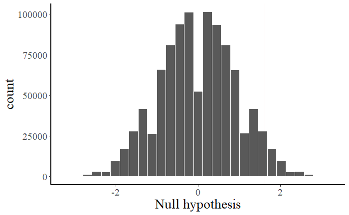

```r
#update this code
diff.dat <- read.csv(file="../Data/ButterflyFishDiffs.csv")
obs.stat <- mean(diff.dat$Difference)
null.vec <-numeric(1e6)

for(i in 1:length(null.vec)) {
  multiplier <- sample(x=c(-1,1), size=length(diff.dat$Difference), replace=TRUE)
  null.vec[i] <- mean(diff.dat$Difference*multiplier)
}

ggplot() + geom_histogram(aes(x=null.vec), col="white") + xlab("Null hypothesis") +
  geom_vline(aes(xintercept=obs.stat), col='red')
```

| # Excercise 3D # |
| --- |

## Two-sample randomization test

Rerun the hotwings example from lecture (using `hotwings.csv`). Update the code to make a million draws from the null distribution. Does the p-value change from the one I reported?

```r
#code here.
hotwings.dat <- read.csv(file="../Data/hotwings.csv")

obs.val <- mean(hotwings.dat$Hotwings[1:14]) - mean(hotwings.dat$Hotwings[15:28])
print(obs.val)
```

```
[1] -5.071429
```

```r
null.vec <- numeric(1e6) #scientific notation for 10000
for(i in 1:1e6) {
  index       <- sample(1:28, 14, replace=F)
  null.vec[i] <- mean(hotwings.dat$Hotwings[index]) - mean(hotwings.dat$Hotwings[-index])
}
p.val <- 2*sum(null.vec < obs.val)/length(null.vec)
print(p.val)
```

```
[1] 0.001904
```

### The p-value is slightly smaller than the one I reported in class. This is more accurate than the one run in class.